# Diversity and Inclusion Report

This report uses randomly generated data and does not reflect the situation in a perticular company.

Dr. Philippe De Brouwer

05 March, 2021

Abstract

This report informs about how diverse the team is and tries to indicate potential areas of bias. This report cannot prove or disprove bias, it can only direct the user to potential problems. Hence this report is in the first place an invitation to think. Much like feedback from other people is an invitation to think and not a diagnosis per se.

# The Particular Example Behind this Demo Report

The data used for this report is randomly generated with the following characteristcs:

# Diversity

## Gender diversity per grade

[figure not shown]

The diversity of the team with respect to gender per grade.

## Age diversity

[figure not shown]

The diversity of the team with respect to age, assuming the age pyramid of the country as reference.

The percentages of different age groups in this team compared to the population of Poland. An equal distribution would yield a diversity of 1.

|  | (20,30] | (30,40] | (40,50] | (50,60] | (60,65] |
| --- | --- | --- | --- | --- | --- |
| team | 0.49 | 0.43 | 0.07 | 0.01 | 0.01 |
| reference | 0.16 | 0.27 | 0.24 | 0.21 | 0.12 |

To calculate the diversity, we assume that the reference population is distributed as in Table . These are the numbers corresponding to Poland.

## Diversity in nationalities

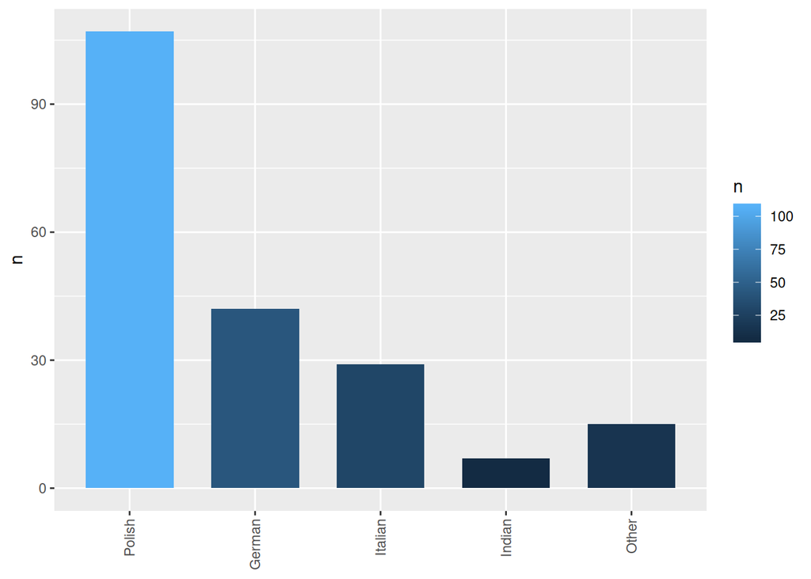

The barplot for the nationalities in the team over all grades.

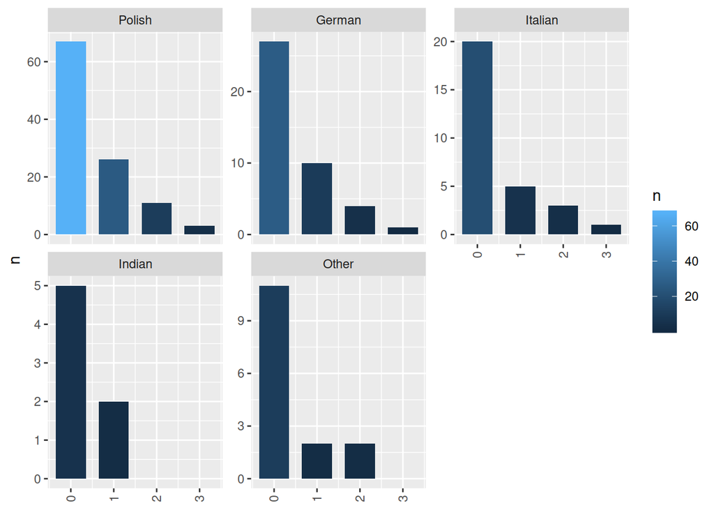

The breakdown of each grade per nationalitiy.

# Inclusion

## Method

We realise that publishing a ``paygap’’ as difference between the average salary of the male and female is not very helpful as this is most likely not measuring a paygap but rather a difference in occupations.

Therefore we only present results of groups that are comparable.

## Legend

- `paygap` = the ratio of median salaries of one group divided by the median of the salaries of the other group
- `NA` = numbers are too small, please look at individuals;
- nothing = no bias detectable;
- `.` = maybe there is some bias, but the numbers are low, check individuals;
- `*` = you should check for bias;
- `**` = bias is probably there;
- `***` = most certainly there is bias

So, there will be more stars if the probability of a bias is higher: this can be due to a higher bias and/or due to a larger sample size.

To improve readability, the column headers are abbreviated. We summarise here the columns and their content:

- `grade` = the salary grade as used in the company
- `jobID` = a unique identifier of the job category (can be abbreviated)
- `sal_F` = the median salary of the females (F), this will be different for other paygap estimations
- `sal_oth` = the median salary of the other groups (non F). The tool is open to use more than one gender. A paygap is expressed as the median of one group compared to others.
- `age_F` = the median age of the females (or `age_Pol` could be the median age of the team members with Polish citizenship)
- `age_oth` = the median age of the other groups take together (e.g. the median age of non females)
- `paygap` = the ratio of median salary earned by the selected group (e.g. females) divided by the median of the other people. So, if this number is lower than one, then median female earns less than the median non-female.
- `conf.` = the confidence level that this paygap is significant and that bias is part of the explanation (for details see in the beginning of this section).

## The Gender PayGap

Table shows the results for the Gender paygap.

The paygap for gender and the confidence level that this paygap is significant alongside the control variable age.

| grade | jobID | sal_F | sal_oth | n_F | n_oths | age_F | age_oth | paygap | conf. |
| --- | --- | --- | --- | --- | --- | --- | --- | --- | --- |
| 0 | sales | 3,971 | 4,274 | 35 | 37 | 30 | 30 | 0.93 | * |
| 0 | analytic | 4,121 | 3,968 | 29 | 29 | 28 | 30 | 1.04 |  |
| 1 | sales | 8,512 | 8,573 | 21 | 9 | 31 | 29 | 0.99 |  |
| 1 | analytic | 8,371 | 8,898 | 9 | 6 | 32 | 29 | 0.94 | . |
| 2 | sales | 17,684 | 19,300 | 4 | 5 | 36 | 36 | 0.92 | NA |
| 2 | analytic | 17,868 | 19,085 | 6 | 5 | 38 | 35 | 0.94 | NA |
| 3 | sales | 37,971 | 39,581 | 1 | 1 | 36 | 62 | 0.96 | NA |
| 3 | analytic | NA | 40,333 | NA | 3 | NA | 35 | NA | NA |

## The Citizenship PayGap

The paygap for citizenship and the confidence level that this paygap is significant alongside the control variable age.

| grade | jobID | sal_oth | sal_Pol | n_oths | n_Polis | age_oth | age_Pol | paygap | conf. |
| --- | --- | --- | --- | --- | --- | --- | --- | --- | --- |
| 0 | sales | 4,132 | 4,120 | 32 | 40 | 30 | 30 | 1.00 |  |
| 0 | analytic | 4,272 | 3,956 | 31 | 27 | 29 | 29 | 0.93 | . |
| 1 | sales | 8,573 | 8,507 | 9 | 21 | 28 | 33 | 0.99 |  |
| 1 | analytic | 8,645 | 7,904 | 10 | 5 | 32 | 27 | 0.91 | NA |
| 2 | sales | 18,945 | 18,058 | 5 | 4 | 36 | 37 | 0.95 | NA |
| 2 | analytic | 17,825 | 18,367 | 4 | 7 | 38 | 35 | 1.03 | NA |
| 3 | sales | 37,971 | 39,581 | 1 | 1 | 36 | 62 | 1.04 | NA |
| 3 | analytic | 40,333 | 40,272 | 1 | 2 | 51 | 34 | 1.00 | NA |